# Machine Learning Project with ROCKET

## Itgel Ganbold

[My Portfolio Website](https://itgelganbold.com)

## Objective

The objective of this assignment is to identify good models for classifying time series data.  
The data is from an accelerometer sensor and there are samples of fatigued and non-fatigued running. The data has been segmented into strides and the segments (samples) are labelled F (fatigued) and NF (not fatigued). The data for two subjects A and B are available in the files `fatigueA.csv` and `fatigueB.csv`. This dataset is extracted from a much larger dataset described [here](https://openreview.net/pdf?id=9c0lAonDNP).  
At present, the best performing method for time-series classification is [Rocket](https://openreview.net/pdf?id=9c0lAonDNP). A rocket implementation is available in the [sktime tool kit](https://www.sktime.net/en/latest/api_reference/auto_generated/sktime.transformations.panel.rocket.Rocket.html). This sktime implementation can be used in this assignment.  
Some code to get you started in available in the notebook `RunningCore`.

```python
# pip install sktime
```

```python
import pandas as pd
import numpy as np
import matplotlib.pyplot as plt
```

```python
fatigue_df = pd.read_csv('fatigueA.csv', header = None)
print(fatigue_df.shape)
fatigue_df.head(5)
```

```
(421, 181)
```

|  | 0 | 1 | 2 | 3 | 4 | 5 | 6 | 7 | 8 | 9 | ... | 171 | 172 | 173 | 174 | 175 | 176 | 177 | 178 | 179 | 180 |
| --- | --- | --- | --- | --- | --- | --- | --- | --- | --- | --- | --- | --- | --- | --- | --- | --- | --- | --- | --- | --- | --- |
| 0 | F | 2.72 | 2.69 | 2.75 | 2.89 | 3.07 | 3.27 | 3.48 | 3.67 | 3.82 | ... | 6.50 | 6.16 | 5.75 | 5.29 | 4.79 | 4.29 | 3.83 | 3.42 | 3.09 | 2.85 |
| 1 | F | 2.68 | 2.47 | 2.46 | 2.54 | 2.69 | 2.93 | 3.36 | 3.99 | 4.75 | ... | 2.79 | 3.88 | 5.18 | 6.29 | 6.88 | 6.80 | 6.13 | 5.11 | 4.04 | 3.20 |
| 2 | F | 5.04 | 5.69 | 6.21 | 6.52 | 6.59 | 6.47 | 6.26 | 6.06 | 5.91 | ... | 5.89 | 5.29 | 4.72 | 4.20 | 3.77 | 3.47 | 3.36 | 3.47 | 3.82 | 4.38 |
| 3 | F | 2.42 | 3.21 | 4.02 | 4.58 | 4.77 | 4.64 | 4.39 | 4.25 | 4.42 | ... | 8.60 | 8.76 | 8.76 | 8.32 | 7.34 | 5.91 | 4.33 | 2.97 | 2.14 | 1.98 |
| 4 | F | 3.35 | 3.40 | 3.89 | 4.71 | 5.66 | 6.47 | 6.90 | 6.81 | 6.25 | ... | 9.45 | 8.52 | 7.75 | 7.14 | 6.63 | 6.15 | 5.60 | 4.96 | 4.28 | 3.69 |

5 rows × 181 columns

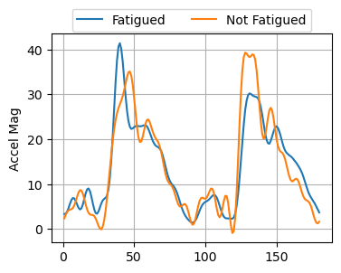

```python
fatigue_df.iloc[4][1:].plot(label='Fatigued') #print the time series for the 4th row
fatigue_df.iloc[-5][1:].plot(figsize=(4,3), label = 'Not Fatigued') #do the same for 5th last row
plt.legend(loc='upper center', bbox_to_anchor=(0.5, 1.15),ncol=2)
plt.ylabel('Accel Mag')
plt.grid();
```

```python
y = fatigue_df.pop(0).values
X = fatigue_df.values
```

```python
#Check null/na values and see if imputation is going to be necessary
print(fatigue_df.isnull().sum().sum())
print(fatigue_df.isnull().sum().sum())
```

```
0
0
```

### Task 1

Calculate the accuracy of a logistic regression classifier (`SGDClassifier`) on the raw time series data for subject A.

```python
X.shape, y.shape
```

```
((421, 180), (421,))
```

```python
from sklearn.linear_model import SGDClassifier
from sklearn.model_selection import train_test_split
from sklearn.metrics import accuracy_score
from sklearn.preprocessing import StandardScaler
```

```python
X_train, X_test, y_train, y_test = train_test_split(X, y, test_size=0.2, random_state=100)
```

```python
sgd_log_classifier = SGDClassifier(loss='log_loss', random_state=100)
sgd_log_classifier.fit(X_train, y_train)

y_sgd_pred = sgd_log_classifier.predict(X_test)
accuracy = accuracy_score(y_test, y_sgd_pred)
print(f"Log Model Accuracy: {accuracy}")
```

```
Log Model Accuracy: 0.8470588235294118
```

```python
x = []
accuracies = []
accuracies_train = []
for i in np.arange(0.1, 1, 0.1):
    X_train_temp, X_test_temp, y_train_temp, y_test_temp = train_test_split(X, y, test_size=i, random_state=100)

    sgd_log_classifier.fit(X_train_temp, y_train_temp)


    y_sgd_pred_temp = sgd_log_classifier.predict(X_test_temp)
    y_sgd_pred_temp_train = sgd_log_classifier.predict(X_train_temp)

    accuracies.append(accuracy_score(y_test_temp, y_sgd_pred_temp))
    accuracies_train.append(accuracy_score(y_train_temp, y_sgd_pred_temp_train))
    x.append(i)
```

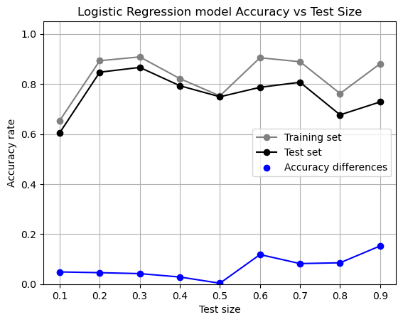

```python
plt.plot(x, accuracies_train, color = 'grey', marker='o', zorder=2, label = "Training set")

plt.plot(x, accuracies, color = 'black', marker='o', zorder=2, label = "Test set")

plt.plot(x, np.array(accuracies_train) - np.array(accuracies) , color = 'blue')
plt.scatter(x, np.array(accuracies_train) - np.array(accuracies) , color = 'blue', zorder=2, label = "Accuracy differences")


plt.grid()
plt.ylim(0, 1.05)
plt.title("Logistic Regression model Accuracy vs Test Size")
plt.xlabel("Test size")
plt.ylabel("Accuracy rate")
plt.legend();
```

```python
print("\nTest-train split of 0.3 gives the best accuracy at: ", round(accuracies[2],2))
```

```
Test-train split of 0.3 gives the best accuracy at:  0.87
```

```python
from sklearn.model_selection import cross_val_score


cv_accuracies = cross_val_score(sgd_log_classifier, X, y, cv= 5, verbose= 0,  n_jobs = -1)
print("Average accuracy score for 5 fold cross validation: ", np.round(np.average(np.array(cv_accuracies)),2))
```

```
Average accuracy score for 5 fold cross validation:  0.77
```

### Task 2

The RunningCore Notebook contains code to convert the data to the `sktime` time-series format. Using this format assess the accuracy of the Rocket transformer coupled with an `SGDClassifier` classifier on the data for subject A.

```python
X3d = X[:,np.newaxis,:] # time series algs require a 3D data array (sample, var, tick)
X3d.shape
```

```
(421, 1, 180)
```

```python
X3d_train, X3d_test, y_train, y_test = train_test_split(X3d, y, test_size=0.3, random_state=100)
```

```python
from sktime.transformations.panel.rocket import Rocket
```

```python
rocket = Rocket()
rocket.fit(X3d_train)
X3d_train_transformed = rocket.transform(X3d_train)
X3d_test_transformed = rocket.transform(X3d_test)
```

```python
sgd_log_classifier = SGDClassifier(loss='log_loss', random_state=100)
sgd_log_classifier.fit(X3d_train_transformed, y_train)
```

```
SGDClassifier(loss='log_loss', random_state=100)
```

```python
y_sgd_pred = sgd_log_classifier.predict(X3d_test_transformed)
accuracy = accuracy_score(y_test, y_sgd_pred)
```

```python
print(f"\nLog loss Model Accuracy with Rocket on test set: {round(accuracy,2)} (with test-set = 0.3)\n")
```

```
Log loss Model Accuracy with Rocket on test set: 0.9 (with test-set = 0.3)
```

```python
y_sgd_pred_training = sgd_log_classifier.predict(X3d_train_transformed)
accuracy_training = accuracy_score(y_train, y_sgd_pred_training)
print(f"\nLog loss Model Accuracy with Rocket on the training set: {round(accuracy_training,2)} (with test-set = 0.3)\n")
```

```
Log loss Model Accuracy with Rocket on the training set: 0.92 (with test-set = 0.3)
```

```python
loss_list = ["hinge", "log_loss", "modified_huber", "squared_hinge", "perceptron",
             "squared_error", "huber", "epsilon_insensitive", "squared_epsilon_insensitive"]
rocket_accuracies = []
rocket_accuracies_on_training = []
rocket_cv_scores = []

for i in loss_list:
    sgd_log_classifier = SGDClassifier(loss=i, random_state=100)
    sgd_log_classifier.fit(X3d_train_transformed, y_train)
    y_sgd_pred = sgd_log_classifier.predict(X3d_test_transformed)
    rocket_accuracies.append(accuracy_score(y_test, y_sgd_pred))

    y_sgd_pred_training = sgd_log_classifier.predict(X3d_train_transformed)
    rocket_accuracies_on_training.append(accuracy_score(y_train, y_sgd_pred_training))

    cv_accuracies = np.average(cross_val_score(sgd_log_classifier, X3d_train_transformed, y_train, cv= 5, verbose= 0,  n_jobs = -1))
    rocket_cv_scores.append(cv_accuracies)
```

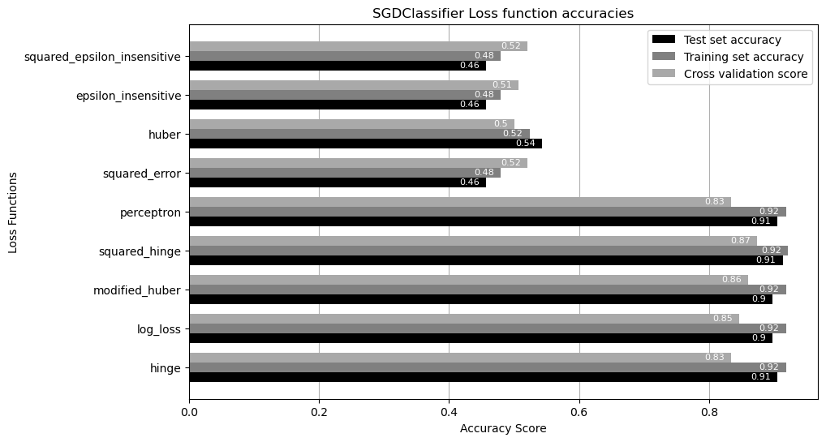

```python
bar_width = 0.25
indices = np.arange(len(loss_list))

plt.figure(figsize=(10,6))


# Adjusting the positions for each bar
adjusted_indices_1 = indices - bar_width
adjusted_indices_2 = indices
adjusted_indices_3 = indices + bar_width

bar_chart1 = plt.barh(adjusted_indices_1, rocket_accuracies, bar_width, color="black", zorder=2, label='Test set accuracy')
bar_chart2 = plt.barh(adjusted_indices_2, rocket_accuracies_on_training, bar_width, color="grey", zorder=2, label='Training set accuracy')
bar_chart3 = plt.barh(adjusted_indices_3, rocket_cv_scores, bar_width, color="darkgrey", zorder=2, label='Cross validation score')

plt.grid(axis='x')
plt.yticks(indices, loss_list)

# Adding text inside bars
def add_bar_text(bars):
    for bar in bars:
        plt.text(
            bar.get_width() - 0.01,
            bar.get_y() + bar.get_height() / 2,
            str(round(bar.get_width(),2)),
            va='center',
            ha='right',
            color='white',
            fontsize=8
        )

add_bar_text(bar_chart1)
add_bar_text(bar_chart2)
add_bar_text(bar_chart3)

plt.legend()
plt.xlabel('Accuracy Score')
plt.ylabel('Loss Functions')
plt.title('SGDClassifier Loss function accuracies')
plt.show()
```

**Note:** Rocket transform seems unstable. Different runs of the relevant cell leads to big differences in accuracy performance. (unsurprisingly, it is random)

We see that the loss function of `hinge`, `squared-hinge` and `perceptron` give the best results with accuracies of 0.91 on test-set, 0.92 on the training set and 0.83, 0.87 and 0.83 on cross-validation respectively.

### Task 3

Evaluate alternatives to see if you can improve the accuracy on the raw data (Task 1). For this, you should consider alternative classifiers and data normalisation. The data should not be transformed beyond normalisation.

#### 3.1 Data Normalization

In terms of normalizations, we have a few options. We could use `MinMaxScaler` normalization, which creates a range [0,1] using the minimum and maximum values or we can use `RobustScaler`, which uses the median and IQR, similar to `StandardScaler`, which we will also use.

```python
from sklearn.preprocessing import MinMaxScaler, RobustScaler
```

```python
X_train, X_test, y_train, y_test = train_test_split(X, y, test_size=0.3, random_state=100)
```

```python
scaler_MM = MinMaxScaler()
X_train_scaled_MM = scaler_MM.fit_transform(X_train)
X_test_scaled_MM = scaler_MM.transform(X_test)

scaler_Rt = RobustScaler()
X_train_scaled_Rt = scaler_Rt.fit_transform(X_train)
X_test_scaled_Rt = scaler_Rt.transform(X_test)

scaler_Ss = StandardScaler()
X_train_scaled_Ss = scaler_Ss.fit_transform(X_train)
X_test_scaled_Ss = scaler_Ss.transform(X_test)
```

```python
sgd_log_classifier = SGDClassifier(loss='log_loss', random_state=100)
sgd_log_classifier.fit(X_train_scaled_MM, y_train)
```

```
SGDClassifier(loss='log_loss', random_state=100)
```

```python
y_sgd_pred_MM = sgd_log_classifier.predict(X_test_scaled_MM)
accuracy = accuracy_score(y_test, y_sgd_pred_MM)
print(f"Log Model Accuracy with MinMaxScaler: {accuracy}")
```

```
Log Model Accuracy with MinMaxScaler: 0.8031496062992126
```

```python
sgd_log_classifier.fit(X_train_scaled_Rt, y_train)
y_sgd_pred_Rt = sgd_log_classifier.predict(X_test_scaled_Rt)
accuracy = accuracy_score(y_test, y_sgd_pred_Rt)
print(f"Log Model Accuracy with RobustScaler: {accuracy}")
```

```
Log Model Accuracy with RobustScaler: 0.8661417322834646
```

```python
sgd_log_classifier.fit(X_train_scaled_Ss, y_train)
y_sgd_pred_Ss = sgd_log_classifier.predict(X_test_scaled_Ss)
accuracy = accuracy_score(y_test, y_sgd_pred_Ss)
print(f"Log Model Accuracy with StandardScaler: {accuracy}")
```

```
Log Model Accuracy with StandardScaler: 0.7086614173228346
```

The above part of the notebook is mainly there to initialize some dataset variables that are scaled using different normalizations. This will be useful later.

We see that controlling for test and training data, `RobustScaler` gives the best accuracy score of 0.87. Second best is the `MinMaxScaler` with 0.80. `StandardScaler` performed the worst with an accuracy score of 0.71, which is surprising, since it is quite similar to the `RobustScaler`. In the grid search below, I will add the scaler as a grid item, so we can double check if the above results are consistent with the grid search.

#### 3.2 Grid Search to find optimal model and parameters

I will check various classifiers and reasonable parameter options to see which model and parameters give he best accuracy score. I will also add the scaler option to double check which scaler gives us the best result as well.

```python
from sklearn.model_selection import GridSearchCV, TimeSeriesSplit
from sklearn.tree import DecisionTreeClassifier
from sklearn.ensemble import RandomForestClassifier, GradientBoostingClassifier
from sklearn.neighbors import KNeighborsClassifier
from sklearn.svm import SVC
from sklearn.naive_bayes import GaussianNB
from sklearn.pipeline import Pipeline
```

```python
#We can do a loop with a grid search to see the intermediate scores for the different classifiers, and also see
#what the accuracy score is on the test set.

classifiers = [
    (RandomForestClassifier(),
     {'classifier__n_estimators': [10, 100, 1000],
      'classifier__max_depth': [5, 10, 15],
      'scaler': [StandardScaler(), RobustScaler(), MinMaxScaler()]}),
    (SVC(),
     {'classifier__C': [1, 10, 100],
      'classifier__kernel': ['linear', 'rbf'],
      'scaler': [StandardScaler(), RobustScaler(), MinMaxScaler()]}),
    (DecisionTreeClassifier(),
     {'classifier__max_depth': [5, 10, 15],
      'scaler': [StandardScaler(), RobustScaler(), MinMaxScaler()]}),
    (KNeighborsClassifier(),
     {'classifier__n_neighbors': [1, 5, 10, 20],
      'scaler': [StandardScaler(), RobustScaler(), MinMaxScaler()]}),
    (SGDClassifier(),
     {'classifier__alpha': [0.0001, 0.001, 0.01],
      'classifier__penalty': ['l2', 'l1', 'elasticnet'],
      'classifier__loss': ['hinge', 'log_loss', 'modified_huber'],
      'scaler': [StandardScaler(), RobustScaler(), MinMaxScaler()]}),
    (GaussianNB(),
     {'classifier__var_smoothing': [1e-9, 1e-8, 1e-7],
      'scaler': [StandardScaler(), RobustScaler(), MinMaxScaler()]})
]

# To preserve the temporal order of the data, use TimeSeriesSplit for cross-validation
tscv = TimeSeriesSplit(n_splits=5)

# Loop over each classifier
for classifier, param_grid in classifiers:
    print(f"\nStarting Grid Search for {classifier.__class__.__name__}")

    # Create a pipeline with the current classifier
    pipeline = Pipeline([('scaler', StandardScaler()),('classifier', classifier)])

    # Set up GridSearchCV
    grid_search = GridSearchCV(estimator=pipeline,
                               param_grid=param_grid,
                               cv=tscv,
                               verbose=1,
                               scoring='accuracy')

    grid_search.fit(X_train, y_train)

    print(f"Best accuracy score (cv) for {classifier.__class__.__name__}: {grid_search.best_score_}")
    print(f"Best parameters for {classifier.__class__.__name__}: {grid_search.best_params_}")

    best_parameters = grid_search.best_params_
    # Create a new pipeline with the best parameters
    best_pipeline = Pipeline([
        ('scaler', best_parameters['scaler']),
        ('classifier', classifier.set_params(**{k.split('__')[1]: v for k, v in best_parameters.items() if k.startswith('classifier__')}))
    ])

    # Fit the best pipeline on the full training data
    best_pipeline.fit(X_train, y_train)

    # Evaluate on the test set
    test_predictions = best_pipeline.predict(X_test)
    test_accuracy = accuracy_score(y_test, test_predictions)
    print(f"Best model accuracy on test set for {classifier.__class__.__name__}: {test_accuracy}")

    # Evaluate on the training set
    train_predictions = best_pipeline.predict(X_train)
    train_accuracy = accuracy_score(y_train, train_predictions)
    print(f"Best model accuracy on train set for {classifier.__class__.__name__}: {train_accuracy}")
```

```
Starting Grid Search for RandomForestClassifier
Fitting 5 folds for each of 27 candidates, totalling 135 fits
Best accuracy score (cv) for RandomForestClassifier: 0.8734693877551021
Best parameters for RandomForestClassifier: {'classifier__max_depth': 10, 'classifier__n_estimators': 100, 'scaler': RobustScaler()}
Best model accuracy on test set for RandomForestClassifier: 0.9133858267716536
Best model accuracy on train set for RandomForestClassifier: 1.0

Starting Grid Search for SVC
Fitting 5 folds for each of 18 candidates, totalling 90 fits
Best accuracy score (cv) for SVC: 0.8938775510204081
Best parameters for SVC: {'classifier__C': 100, 'classifier__kernel': 'rbf', 'scaler': MinMaxScaler()}
Best model accuracy on test set for SVC: 0.9606299212598425
Best model accuracy on train set for SVC: 1.0

Starting Grid Search for DecisionTreeClassifier
Fitting 5 folds for each of 9 candidates, totalling 45 fits
Best accuracy score (cv) for DecisionTreeClassifier: 0.7591836734693878
Best parameters for DecisionTreeClassifier: {'classifier__max_depth': 5, 'scaler': MinMaxScaler()}
Best model accuracy on test set for DecisionTreeClassifier: 0.7795275590551181
Best model accuracy on train set for DecisionTreeClassifier: 0.9625850340136054

Starting Grid Search for KNeighborsClassifier
Fitting 5 folds for each of 12 candidates, totalling 60 fits
Best accuracy score (cv) for KNeighborsClassifier: 0.8285714285714285
Best parameters for KNeighborsClassifier: {'classifier__n_neighbors': 10, 'scaler': RobustScaler()}
Best model accuracy on test set for KNeighborsClassifier: 0.8346456692913385
Best model accuracy on train set for KNeighborsClassifier: 0.8639455782312925

Starting Grid Search for SGDClassifier
Fitting 5 folds for each of 81 candidates, totalling 405 fits
Best accuracy score (cv) for SGDClassifier: 0.8653061224489796
Best parameters for SGDClassifier: {'classifier__alpha': 0.0001, 'classifier__loss': 'log_loss', 'classifier__penalty': 'l1', 'scaler': StandardScaler()}
Best model accuracy on test set for SGDClassifier: 0.84251968503937
Best model accuracy on train set for SGDClassifier: 0.935374149659864

Starting Grid Search for GaussianNB
Fitting 5 folds for each of 9 candidates, totalling 45 fits
Best accuracy score (cv) for GaussianNB: 0.6938775510204082
Best parameters for GaussianNB: {'classifier__var_smoothing': 1e-09, 'scaler': StandardScaler()}
Best model accuracy on test set for GaussianNB: 0.7165354330708661
Best model accuracy on train set for GaussianNB: 0.7108843537414966
```

We have performed a grid search using various classifiers and performed 5-fold cross-validation. The best parameters were found to be the `SVC` classifier with `C` value of 100 and `kernel`= rbf with `MinMaxScaler`. Now that we have our ideal classifier, we can do further optimizations to improve the model accuracy.

At this point it is important to clarify what we are truly after. We want to find the model that has the highest accuracy rate on the test set as well as the cross-validation score, overfitting is not a major concern but we will test the model on the training set as a matter of interest.

I also want to note that `SGDClassifier` fitted a total of 405 models, and the process was quite fast.

Let us now increase the grid search granularity and see if we can further increase the accuracy score of our model.

```python
# We can do a loop with a grid search to see the intermediate scores for the different classifiers, and also see
# what the accuracy score is on the test set.

classifiers = [
    (SVC(),
     {'classifier__C': [50, 60, 70, 80, 90, 100, 110, 120, 130],
      'classifier__kernel': ['linear', 'rbf'],
      'scaler': [StandardScaler(), RobustScaler(), MinMaxScaler()]})
]

tscv = TimeSeriesSplit(n_splits=5)

# Loop over each classifier
for classifier, param_grid in classifiers:
    print(f"\nStarting Grid Search for {classifier.__class__.__name__}")

    # Create a pipeline with the current classifier
    pipeline = Pipeline([('scaler', StandardScaler()),('classifier', classifier)])

    # Set up GridSearchCV
    grid_search = GridSearchCV(estimator=pipeline,
                               param_grid=param_grid,
                               cv=tscv,
                               verbose=1,
                               scoring='accuracy')

    grid_search.fit(X_train, y_train)

    print(f"Best accuracy score (cv) for {classifier.__class__.__name__}: {grid_search.best_score_}")
    print(f"Best parameters for {classifier.__class__.__name__}: {grid_search.best_params_}")

    best_parameters = grid_search.best_params_
    # Create a new pipeline with the best parameters
    best_pipeline = Pipeline([
        ('scaler', best_parameters['scaler']),
        ('classifier', classifier.set_params(**{k.split('__')[1]: v for k, v in best_parameters.items() if k.startswith('classifier__')}))
    ])

    # Fit the best pipeline on the full training data
    best_pipeline.fit(X_train, y_train)

    # Evaluate on the test set
    test_predictions = best_pipeline.predict(X_test)
    test_accuracy = accuracy_score(y_test, test_predictions)
    print(f"Best model accuracy on test set for {classifier.__class__.__name__}: {test_accuracy}")

    # Evaluate on the training set
    train_predictions = best_pipeline.predict(X_train)
    train_accuracy = accuracy_score(y_train, train_predictions)
    print(f"Best model accuracy on train set for {classifier.__class__.__name__}: {train_accuracy}")
```

```
Starting Grid Search for SVC
Fitting 5 folds for each of 54 candidates, totalling 270 fits
Best accuracy score (cv) for SVC: 0.8938775510204081
Best parameters for SVC: {'classifier__C': 50, 'classifier__kernel': 'rbf', 'scaler': MinMaxScaler()}
Best model accuracy on test set for SVC: 0.9606299212598425
Best model accuracy on train set for SVC: 1.0
```

Tightening the search parameters for `C` lead to a different parameter set, but the results are completely identical on all 3 metrics.

To recap our findings, the best model and parameters are:

- **Normalization**: `MinMaxScaler()`
- **Optimal Model Parameters**: `SVC(C=50.0, kernel='rbf')`

### Task 4

Evaluate alternatives to improve accuracy using the Rocket transformer. Test the Rocket transformer with different numbers of kernels. Consider alternative models for the classifier stage. Again, only the data for subject A should be considered. What conclusions can you draw?

#### 4.1 Number of kernels

First, let's see how the number of kernels change the accuracy score on our previous Stochastic Gradient Descent Classifier. We know that the kernel is what dictates the size of the model feature space. This means, we control the model complexity, computational efficiency and overall generalization with this one parameter.

We could add the kernel number as a grid entry in a grid search, but we cannot visualize it in that case. So I will keep it separate in order to see it visually. Also, data transformation using Rocket is painfully slow.

```python
def kernel_plotter(start, end, interval):
    acc_test = []
    acc_train = []

    for i in range(start, end, interval):
        rocket = Rocket(num_kernels=i)
        rocket.fit(X3d_train)

        X3d_train_transformed = rocket.transform(X3d_train)
        X3d_test_transformed = rocket.transform(X3d_test)

        sgd_log_classifier = SGDClassifier(loss='log_loss', random_state=100)
        sgd_log_classifier.fit(X3d_train_transformed, y_train)

        y_sgd_pred = sgd_log_classifier.predict(X3d_test_transformed)
        acc_test.append(accuracy_score(y_test, y_sgd_pred))

        y_sgd_pred_training = sgd_log_classifier.predict(X3d_train_transformed)
        acc_train.append(accuracy_score(y_train, y_sgd_pred_training))

    return acc_test, acc_train


acc_test, acc_train = kernel_plotter(1000, 20000, 1000)
```

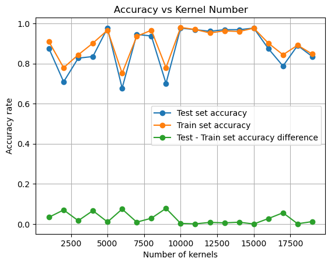

```python
ker = range(1000, 20000, 1000)
plt.plot(ker, acc_test, zorder = 2, label="Test set accuracy", marker='o')

plt.plot(ker, acc_train, zorder = 2, label="Train set accuracy", marker='o')

plt.plot(ker, abs(np.array(acc_train) - np.array(acc_test)), zorder = 2, label="Test - Train set accuracy difference", marker='o')

plt.xlabel("Number of kernels")
plt.ylabel("Accuracy rate")
plt.title("Accuracy vs Kernel Number")

plt.legend()

plt.grid()
```

There seem to be no discernible trend in the model accuracy as `num_kernel` is varied. Keep in mind that the default value is 10,000.

We see that setting `num_kernel` to 10000 gives the best overall result for the accuracy on the test set. And, surprisingly, the test set accuracy and train set accuracy scores are nearly identical.

```python
rocket = Rocket(num_kernels=10000)
rocket.fit(X3d_train)

X3d_train_transformed = rocket.transform(X3d_train)
X3d_test_transformed = rocket.transform(X3d_test)


#We can do a loop with a grid search to see the intermediate scores for the different classifiers, and also see
#what the accuracy score is on the test set.

classifiers = [
    (RandomForestClassifier(),
     {'classifier__n_estimators': [10, 100, 1000],
      'classifier__max_depth': [5, 10, 15]}),
    (SVC(),
     {'classifier__C': [1, 10, 100],
      'classifier__kernel': ['linear', 'rbf']}),
    (DecisionTreeClassifier(),
     {'classifier__max_depth': [5, 10, 15]}),
    (KNeighborsClassifier(),
     {'classifier__n_neighbors': [1, 5, 10, 20]}),
    (SGDClassifier(),
     {'classifier__alpha': [0.0001, 0.001, 0.01],
      'classifier__penalty': ['l2', 'l1', 'elasticnet'],
      'classifier__loss': ['hinge', 'log_loss', 'modified_huber']}),
    (GaussianNB(),
     {'classifier__var_smoothing': [1e-9, 1e-8, 1e-7]})
]

# To preserve the temporal order of the data, use TimeSeriesSplit for cross-validation
tscv = TimeSeriesSplit(n_splits=5)

# Loop over each classifier
for classifier, param_grid in classifiers:
    print(f"\nStarting Grid Search for {classifier.__class__.__name__}")

    # Create a pipeline with the current classifier
    pipeline = Pipeline([('classifier', classifier)])

    # Set up GridSearchCV
    grid_search = GridSearchCV(estimator=pipeline,
                               param_grid=param_grid,
                               cv=tscv,
                               verbose=1,
                               scoring='accuracy')

    grid_search.fit(X3d_train_transformed, y_train)

    print(f"Best accuracy score (cv) for {classifier.__class__.__name__}: {grid_search.best_score_}")
    print(f"Best parameters for {classifier.__class__.__name__}: {grid_search.best_params_}")

    best_parameters = grid_search.best_params_
    # Create a new pipeline with the best parameters
    best_pipeline = Pipeline([
        ('classifier', classifier.set_params(**{k.split('__')[1]: v for k, v in best_parameters.items() if k.startswith('classifier__')}))
    ])

    # Fit the best pipeline on the full training data
    best_pipeline.fit(X3d_train_transformed, y_train)

    # Evaluate on the test set
    test_predictions = best_pipeline.predict(X3d_test_transformed)
    test_accuracy = accuracy_score(y_test, test_predictions)
    print(f"Best model accuracy on test set for {classifier.__class__.__name__}: {test_accuracy}")

    # Evaluate on the training set
    train_predictions = best_pipeline.predict(X3d_train_transformed)
    train_accuracy = accuracy_score(y_train, train_predictions)
    print(f"Best model accuracy on train set for {classifier.__class__.__name__}: {train_accuracy}")
```

```
Starting Grid Search for RandomForestClassifier
Fitting 5 folds for each of 9 candidates, totalling 45 fits
Best accuracy score (cv) for RandomForestClassifier: 0.9306122448979594
Best parameters for RandomForestClassifier: {'classifier__max_depth': 5, 'classifier__n_estimators': 1000}
Best model accuracy on test set for RandomForestClassifier: 0.984251968503937
Best model accuracy on train set for RandomForestClassifier: 1.0

Starting Grid Search for SVC
Fitting 5 folds for each of 6 candidates, totalling 30 fits
Best accuracy score (cv) for SVC: 0.926530612244898
Best parameters for SVC: {'classifier__C': 1, 'classifier__kernel': 'linear'}
Best model accuracy on test set for SVC: 0.984251968503937
Best model accuracy on train set for SVC: 1.0

Starting Grid Search for DecisionTreeClassifier
Fitting 5 folds for each of 3 candidates, totalling 15 fits
Best accuracy score (cv) for DecisionTreeClassifier: 0.8408163265306122
Best parameters for DecisionTreeClassifier: {'classifier__max_depth': 10}
Best model accuracy on test set for DecisionTreeClassifier: 0.8818897637795275
Best model accuracy on train set for DecisionTreeClassifier: 1.0

Starting Grid Search for KNeighborsClassifier
Fitting 5 folds for each of 4 candidates, totalling 20 fits
Best accuracy score (cv) for KNeighborsClassifier: 0.8489795918367348
Best parameters for KNeighborsClassifier: {'classifier__n_neighbors': 5}
Best model accuracy on test set for KNeighborsClassifier: 0.9212598425196851
Best model accuracy on train set for KNeighborsClassifier: 0.9217687074829932

Starting Grid Search for SGDClassifier
Fitting 5 folds for each of 27 candidates, totalling 135 fits
Best accuracy score (cv) for SGDClassifier: 0.8857142857142858
Best parameters for SGDClassifier: {'classifier__alpha': 0.0001, 'classifier__loss': 'modified_huber', 'classifier__penalty': 'l1'}
Best model accuracy on test set for SGDClassifier: 0.968503937007874
Best model accuracy on train set for SGDClassifier: 0.9523809523809523

Starting Grid Search for GaussianNB
Fitting 5 folds for each of 3 candidates, totalling 15 fits
Best accuracy score (cv) for GaussianNB: 0.8571428571428571
Best parameters for GaussianNB: {'classifier__var_smoothing': 1e-08}
Best model accuracy on test set for GaussianNB: 0.8661417322834646
Best model accuracy on train set for GaussianNB: 0.8707482993197279
```

Going by the cross-validations core, the best model is RandomForestClassifier as it has accuracy of 0.98 and cross-validation score of 0.93.

Let us see if we can improve on these results by fine tuning the parameters. First, we will investigate the impact of `n_estimators` on the model.

```python
acc_test_rfc = []
acc_train_rfc = []

for i in range(10, 200, 10):
    RFC = RandomForestClassifier(max_depth=3, n_estimators=i)
    RFC.fit(X3d_train_transformed, y_train)

    y_rfc_pred = RFC.predict(X3d_test_transformed)

    accuracy_rfc = accuracy_score(y_test, y_rfc_pred)
    acc_test_rfc.append(accuracy_rfc)

    y_rfc_pred_train = RFC.predict(X3d_train_transformed)
    acc_train_rfc.append(accuracy_score(y_train, y_rfc_pred_train));
```

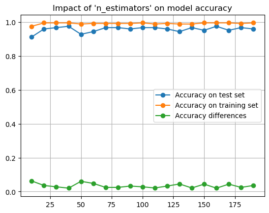

```python
plt.plot(range(10, 200, 10), acc_test_rfc, zorder=2, label="Accuracy on test set", marker='o')

plt.plot(range(10, 200, 10), acc_train_rfc, zorder=2, label="Accuracy on training set", marker='o')

plt.plot(range(10, 200, 10), abs(np.array(acc_train_rfc)-np.array(acc_test_rfc)),
            zorder=2, label="Accuracy differences", marker='o')


plt.title("Impact of 'n_estimators' on model accuracy")
plt.legend()
plt.grid()
```

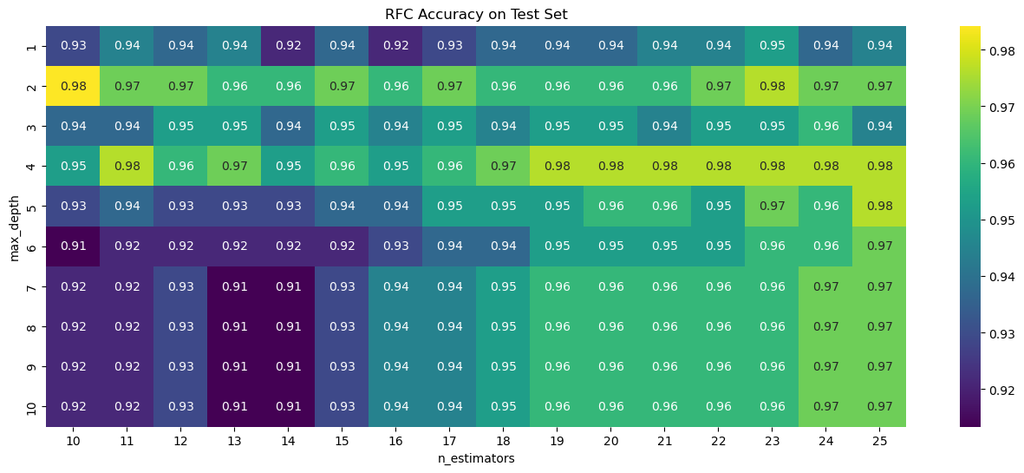

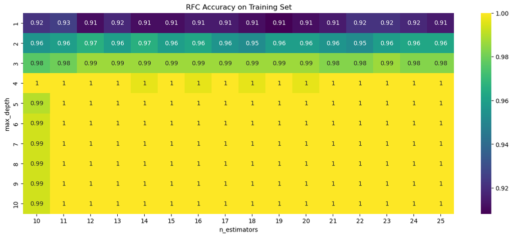

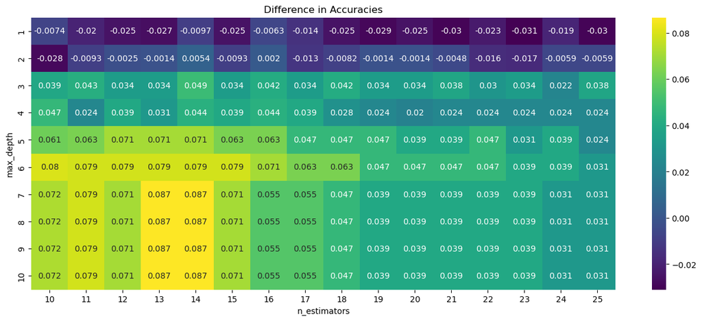

```python
import seaborn as sns
import matplotlib.pyplot as plt


depth_range = range(1, 11)
estimators_range = range(10, 26)

accuracy_test = np.zeros((len(depth_range), len(estimators_range)))
accuracy_train = np.zeros_like(accuracy_test)


for i, max_depth in enumerate(depth_range):
    for j, n_estimators in enumerate(estimators_range):
        RFC = RandomForestClassifier(max_depth=max_depth, n_estimators=n_estimators, random_state=100)
        RFC.fit(X3d_train_transformed, y_train)


        y_pred_test = RFC.predict(X3d_test_transformed) # Predict and calculate accuracy on test set
        accuracy_test[i, j] = accuracy_score(y_test, y_pred_test)


        y_pred_train = RFC.predict(X3d_train_transformed) # Predict and calculate accuracy on training set
        accuracy_train[i, j] = accuracy_score(y_train, y_pred_train)

accuracy_diff = accuracy_train - accuracy_test


# Function to plot heatmap
def plot_heatmap(data, title, xlabel, ylabel):
    plt.figure(figsize=(16, 6))
    sns.heatmap(data, annot=True, cmap='viridis', xticklabels=estimators_range, yticklabels=depth_range)
    plt.title(title)
    plt.xlabel(xlabel)
    plt.ylabel(ylabel)
    plt.show()

# Plotting accuracy heatmaps will help us determine the optimal parameters for our RFClassifier as we are
# only varying 2 parameters.
plot_heatmap(accuracy_test, "RFC Accuracy on Test Set", "n_estimators", "max_depth")
plot_heatmap(accuracy_train, "RFC Accuracy on Training Set", "n_estimators", "max_depth")
plot_heatmap(accuracy_diff, "Difference in Accuracies", "n_estimators", "max_depth")
```

Utilizing a `RandomForestClassifier` within our specified parameter ranges, the highest accuracy achieved on the test set is 0.98 where the corresponding train set accuracy is 0.96.

So, to recap out efforts in this task:

- `RandomForestClassifier(max_depth=2, n_estimators=10)`

To recap our finding thus far for this task, we have:

- `num_kernels = 10000`
- `RandomForestClassifier(max_depth=2, n_estimators=10)`

### Task 5

Test to see if the main conclusions from Tasks 3 and 4 hold up with the data for subject B. Comment on your findings.

```python
fatigue_df_b = pd.read_csv('fatigueB.csv', header = None)
print(fatigue_df_b.shape)
fatigue_df_b.head(5)

y_b = fatigue_df_b.pop(0).values
X_b = fatigue_df_b.values
```

```
(251, 181)
```

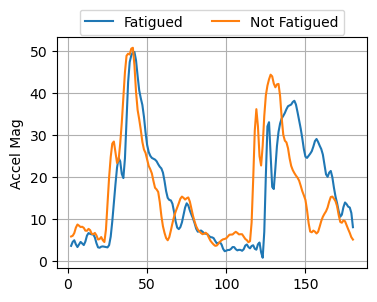

```python
fatigue_df_b.iloc[4][1:].plot(label='Fatigued')
fatigue_df_b.iloc[-5][1:].plot(figsize=(4,3), label = 'Not Fatigued')
plt.legend(loc='upper center', bbox_to_anchor=(0.5, 1.15),ncol=2)
plt.ylabel('Accel Mag')
plt.grid();
```

#### 5.1 Task 3 optimization for Subject B

```python
X_train_b, X_test_b, y_train_b, y_test_b = train_test_split(X_b, y_b, test_size=0.4, random_state=100)
sgd_log_classifier = SGDClassifier(loss='log_loss', random_state=100)
sgd_log_classifier.fit(X_train_b, y_train_b)

y_sgd_pred_b = sgd_log_classifier.predict(X_test_b)
accuracy_b = accuracy_score(y_test_b, y_sgd_pred_b)
print(f"Log Model Accuracy on test set for subject B: {accuracy_b}")

y_sgd_pred_train_b = sgd_log_classifier.predict(X_train_b)
accuracy_train_b = accuracy_score(y_train_b, y_sgd_pred_train_b)
print(f"Log Model Accuracy on train set for subject B: {accuracy_train_b}")

cv_accuracies = cross_val_score(sgd_log_classifier, X_b, y_b, cv= 5, verbose= 0,  n_jobs = -1)
print("Average accuracy score for 5 fold cross validation for subject B: ", np.round(np.average(np.array(cv_accuracies)),2))
```

```
Log Model Accuracy on test set for subject B: 0.8613861386138614
Log Model Accuracy on train set for subject B: 0.9133333333333333
Average accuracy score for 5 fold cross validation for subject B:  0.74
```

```python
scaler_MM = MinMaxScaler()
X_train_b_scaled_MM = scaler_MM.fit_transform(X_train_b)
X_test_b_scaled_MM = scaler_MM.transform(X_test_b)
X_b_scaled_MM = scaler_MM.fit_transform(X_b)

SVM = SVC(C=1, kernel='rbf')
SVM.fit(X_train_b_scaled_MM, y_train_b)

print("MinMaxScaler, C=1, rbf kernel")

y_svm_pred_b = SVM.predict(X_test_b_scaled_MM)

accuracy_svm_b = accuracy_score(y_test_b, y_svm_pred_b)
print("SVClassifier Accuracy on test set for subject B: ", accuracy_svm_b)

y_svm_pred_train_b = SVM.predict(X_train_b_scaled_MM)
accuracy_svm_train_b = accuracy_score(y_train_b, y_svm_pred_train_b)
print("SVClassifier Accuracy on training set for subject B: ", accuracy_svm_train_b)

cv_accuracies = cross_val_score(SVM, X_b_scaled_MM, y_b, cv= 5, verbose= 0,  n_jobs = -1)
print("Average accuracy score for 5 fold cross validation for subject B using SVM: ", np.round(np.average(np.array(cv_accuracies)),2))
```

```
MinMaxScaler, C=1, rbf kernel
SVClassifier Accuracy on test set for subject B:  0.8613861386138614
SVClassifier Accuracy on training set for subject B:  0.94
Average accuracy score for 5 fold cross validation for subject B using SVM:  0.85
```

The score to beat here was 86% for the test set accuracy, 91% for the training set accuracy and 74% for the cross-validation score. We have managed to improve upon the cross-validation score by about 11%, up to 85%, which is substantial. Only the accuracy on the test set remained largely unchanged. Let's see how this compares to subject A.

[output not shown]

As we see, the performance improvements for subject A were much more pronounced compared to subject B.

For the next part, I will check if a model that was trained on subject A will generalize to subject B.

#### 5.2 Testing global models on subject B

```python
sgd_log_classifier = SGDClassifier(loss='log_loss', random_state=100)
sgd_log_classifier.fit(X_train, y_train)

y_sgd_pred = sgd_log_classifier.predict(X_b)
accuracy = accuracy_score(y_b, y_sgd_pred)
print(f"Log Model Accuracy (trained on subject A) tested on subject B: {accuracy}")
```

```
Log Model Accuracy (trained on subject A) tested on subject B: 0.4820717131474104
```

```python
X_b_scaled_MM = scaler_MM.fit_transform(X_b)

print("MinMaxScaler, C=1, rbf kernel")

SVM = SVC(C=1, kernel='rbf')
SVM.fit(X_train_scaled_MM, y_train)

y_svm_pred = SVM.predict(X_b_scaled_MM)
accuracy_svm = accuracy_score(y_b, y_svm_pred)
print("SVClassifier Accuracy (trained on subject A) tested on subject B set: ", accuracy_svm)
```

```
MinMaxScaler, C=1, rbf kernel
SVClassifier Accuracy (trained on subject A) tested on subject B set:  0.3665338645418327
```

We have tried to see how well the best performing models that were trained on subject A would perform on subject B. The results are unsurprisingly poor as it was indicated by the given hint. The models may have generalized well for subject A, but this generalization does not extend to subject B. In other words, we cannot treat these models as good 'global' models as they are trained on only one subject and they seem to learn subject specific information as opposed to more general information that can be applied to all subjects.

#### 5.3 Task 4 optimizations on Subject B

```python
X3d_b = X_b[:,np.newaxis,:] # time series algs require a 3D data array (sample, var, tick)

X3d_b_train, X3d_b_test, y_b_train, y_b_test = train_test_split(X3d_b, y_b, test_size=0.3, random_state=100)

rocket = Rocket()
rocket.fit(X3d_b_train)
X3d_b_train_transformed = rocket.transform(X3d_b_train)
X3d_b_test_transformed = rocket.transform(X3d_b_test)
X3d_b_transformed = rocket.transform(X3d_b)

sgd_log_classifier = SGDClassifier(loss='log_loss', random_state=100)
sgd_log_classifier.fit(X3d_b_train_transformed, y_b_train)

y_sgd_pred = sgd_log_classifier.predict(X3d_b_test_transformed)
accuracy = accuracy_score(y_b_test, y_sgd_pred)

print(f"\nLog loss Model Accuracy with Rocket on test set for subject B: {round(accuracy,2)} (with test-set = 0.3)\n")

y_sgd_pred_training = sgd_log_classifier.predict(X3d_b_train_transformed)
accuracy_training = accuracy_score(y_b_train, y_sgd_pred_training)
print(f"\nLog loss Model Accuracy with Rocket on the training set for subject B: {round(accuracy_training,2)} (with test-set = 0.3)\n")

loss_list = ["hinge", "log_loss", "modified_huber", "squared_hinge", "perceptron",
             "squared_error", "huber", "epsilon_insensitive", "squared_epsilon_insensitive"]
rocket_accuracies = []
rocket_accuracies_on_training = []
rocket_cv_scores = []

for i in loss_list:
    sgd_log_classifier = SGDClassifier(loss=i, random_state=100)
    sgd_log_classifier.fit(X3d_b_train_transformed, y_b_train)

    y_sgd_pred = sgd_log_classifier.predict(X3d_b_test_transformed)
    rocket_accuracies.append(accuracy_score(y_b_test, y_sgd_pred))

    y_sgd_pred_training = sgd_log_classifier.predict(X3d_b_train_transformed)
    rocket_accuracies_on_training.append(accuracy_score(y_b_train, y_sgd_pred_training))

    cv_accuracies = np.average(cross_val_score(sgd_log_classifier, X3d_b_transformed, y_b, cv= 5, verbose= 0,  n_jobs = -1))
    rocket_cv_scores.append(cv_accuracies)
```

```
Log loss Model Accuracy with Rocket on test set for subject B: 0.93 (with test-set = 0.3)


Log loss Model Accuracy with Rocket on the training set for subject B: 0.96 (with test-set = 0.3)
```

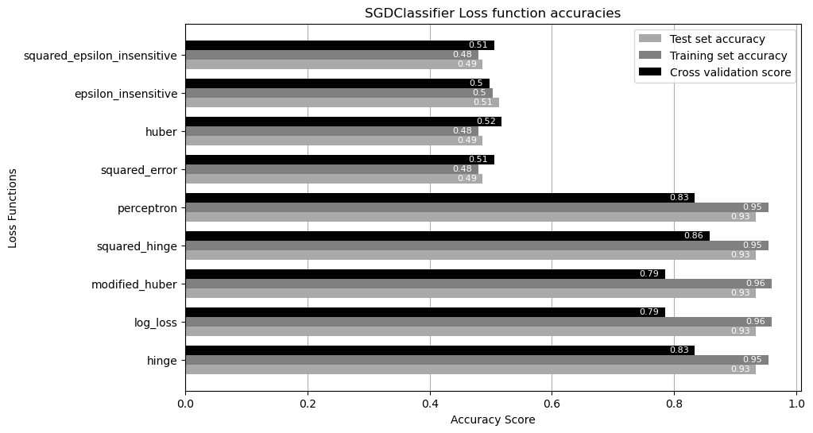

```python
bar_width = 0.25
indices = np.arange(len(loss_list))

plt.figure(figsize=(10,6))


# Adjusting the positions for each bar
adjusted_indices_1 = indices - bar_width
adjusted_indices_2 = indices
adjusted_indices_3 = indices + bar_width

bar_chart1 = plt.barh(adjusted_indices_1, rocket_accuracies, bar_width, color="darkgrey", zorder=2, label='Test set accuracy')
bar_chart2 = plt.barh(adjusted_indices_2, rocket_accuracies_on_training, bar_width, color="grey", zorder=2, label='Training set accuracy')
bar_chart3 = plt.barh(adjusted_indices_3, rocket_cv_scores, bar_width, color="black", zorder=2, label='Cross validation score')

plt.grid(axis='x')
plt.yticks(indices, loss_list)

# Adding text inside bars
def add_bar_text(bars):
    for bar in bars:
        plt.text(
            bar.get_width() - 0.01,
            bar.get_y() + bar.get_height() / 2,
            str(round(bar.get_width(),2)),
            va='center',
            ha='right',
            color='white',
            fontsize=8
        )

add_bar_text(bar_chart1)
add_bar_text(bar_chart2)
add_bar_text(bar_chart3)

plt.legend()
plt.xlabel('Accuracy Score')
plt.ylabel('Loss Functions')
plt.title('SGDClassifier Loss function accuracies')
plt.show();
```

Next, we will check how our best model from Task 4 perform. Recall that our best parameters were:

- `RandomForestClassifier(max_depth=2, n_estimators=10)`
- `num_kernels = 10000`

```python
rocket = Rocket(num_kernels=10000)
rocket.fit(X3d_b_train)

X3d_b_train_transformed = rocket.transform(X3d_b_train)
X3d_b_test_transformed = rocket.transform(X3d_b_test)


RFC = RandomForestClassifier(max_depth=2, n_estimators=10, random_state=100)
RFC.fit(X3d_b_train_transformed, y_b_train)


y_pred_test = RFC.predict(X3d_b_test_transformed)
accuracy_test = accuracy_score(y_b_test, y_pred_test)
print("RandomForestClassifier accuracy on test set for subject B:", accuracy_test)

y_pred_train = RFC.predict(X3d_b_train_transformed)
accuracy_train = accuracy_score(y_b_train, y_pred_train)
print("RandomForestClassifier accuracy on train set for subject B:", accuracy_train)

cv_accuracies = np.average(cross_val_score(RFC, X3d_b_transformed, y_b, cv= 5, verbose= 0,  n_jobs = -1))
print("RandomForestClassifier 5 fold cross validation accuracy score on subject B:", cv_accuracies)
```

```
RandomForestClassifier accuracy on test set for subject B: 0.9473684210526315
RandomForestClassifier accuracy on train set for subject B: 0.9828571428571429
RandomForestClassifier 5 fold cross validation accuracy score on subject B: 0.8888627450980392
```

The model that performed well for subject A does well for subject B, although the differences aren't as drastic. Let's see how these improvements compare with subject A:

[output not shown]